```python
'Course:Graph Theory Project(MADS2023-2024)'
'Name: Yashar Movahedi'
'Student Id:0232113102'
```

```
'Student Id:0232113102'
```

```python
from main import build_decision_tree,predict_label
import matplotlib.pyplot as plt
import pandas as pd
import numpy as np
```

```python
# Assuming this is where you load your data and train the decision tree
data = pd.read_csv('project(1).csv')
values = data['V1'].values
labels = data['V2'].values

# Build the decision tree
decision_tree = build_decision_tree(values, labels)
```

[output not shown]

```python
# Step 3: Predict labels for new observations
new_observations = [1.2, -4, 3]
## Iterate through each new observation and make predictions
for observation in new_observations:
    predicted_label = predict_label(decision_tree, observation)
    print(f'Prediction for observation {observation}: Label {predicted_label}')
```

```
Prediction for observation 1.2: Label 0
Prediction for observation -4: Label 0
Prediction for observation 3: Label 0
```

```python
from IPython.display import Latex, display

# Your LaTeX code
latex_code = r"""
\[
P_1 = \left|\{x_i \mid v(x_i) < c_1\}\right| \quad \text{and} \quad Q_1 = \left|\{x_i \mid v(x_i) > c_1\}\right|,
\]

\[
p_1 = \frac{1}{P_1}\sum_{x_i : v(x_i) < c_1} l(x_i) \quad \text{and} \quad q_1 = \frac{1}{Q_1}\sum_{x_i : v(x_i) > c_1} l(x_i).
\]

Here \(p_1\) and \(q_1\) represent the proportion of label 1 observations in the subsets made of the observations respectively smaller and larger than \(c_1\). You will choose \(c_1\) such that it minimizes

\[
P_1p_1(1 - p_1) + Q_1q_1(1 - q_1),
\]

the so-called Gini impurity.
"""

# Display the LaTeX code
display(Latex(latex_code))
```

\[ P_1 = \left|\{x_i \mid v(x_i) < c_1\}\right| \quad \text{and} \quad Q_1 = \left|\{x_i \mid v(x_i) > c_1\}\right|, \] \[ p_1 = \frac{1}{P_1}\sum_{x_i : v(x_i) < c_1} l(x_i) \quad \text{and} \quad q_1 = \frac{1}{Q_1}\sum_{x_i : v(x_i) > c_1} l(x_i). \] Here \(p_1\) and \(q_1\) represent the proportion of label 1 observations in the subsets made of the observations respectively smaller and larger than \(c_1\). You will choose \(c_1\) such that it minimizes \[ P_1p_1(1 - p_1) + Q_1q_1(1 - q_1), \] the so-called Gini impurity.

P1 represents the count of observations (xi) where the value v(xi) is less than c1.\ Q1 represents the count of observations (xi) where the value v(xi) is greater than c1.\ In these formulas, we will build a decision tree, a tool that predicts outcomes. Think of a bunch of observations,we're figuring out the best way to split them using a value c1. The counts P1 and Q1 show how many are on each side, while p1 and q1 tell us the label proportions in each group.\ Our goal?is to pick c1 in a way that makes both groups as pure as possible. This helps our decision tree make accurate predictions for new observations.

```python
# Generate predictions on the training dataset using the decision tree
## Calculate the accuracy by comparing predicted labels with actual labels
train_prediction = [predict_label(decision_tree, o) for o in values]
print(np.sum((labels == train_prediction) ** 2)/labels.shape[0])
```

```
0.81
```

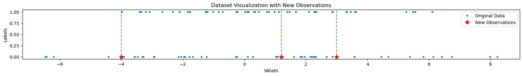

```python
# Visualize the dataset and highlight new observations on the plot and Add vertical lines for each new observation (in green)
#plt.figure(figsize=(20, 2))
#plt.plot(data['V1'], data['V2'], '.')
#for x in new_observations:
    #plt.axvline(x, color='green')

#plt.xlabel('Values')
#plt.ylabel('Labels')
#plt.show()
# Visualize the dataset and highlight new observations on the plot with vertical green lines
plt.figure(figsize=(20, 2))

# Plot the dataset
plt.plot(data['V1'], data['V2'], '.', label='Original Data')

# Highlight new observations with red stars
plt.plot(new_observations, [0] * len(new_observations), 'r*', markersize=10, label='New Observations')

# Add vertical lines for each new observation (in green)
for x in new_observations:
    plt.axvline(x, color='green', linestyle='--', alpha=0.7)

# Set plot labels and title
plt.xlabel('Values')
plt.ylabel('Labels')
plt.title('Dataset Visualization with New Observations')

# Add legend
plt.legend()

# Display the plot
plt.show()
```

The decision tree model achieved an accuracy of 81% on the training dataset, indicating a reasonable level of performance. However, the predictions for the new observations all resulted in the label "0." This might suggest a potential issue with the model, dataset, or feature representation that needs further investigation.